# IODS course project

Mikko Salonen

# About the project

This is the start of my course diary (check the link). Updates coming soon.

### Description of the course

In this course I will learn about:

- R
- R Markdown
- git
- Data analysis

### My github repository

https://github.com/maasal/IODS-project

### My course diary

https://maasal.github.io/IODS-project/

#### Useful links

[R Markdown cheatsheet](https://www.rstudio.com/wp-content/uploads/2015/02/rmarkdown-cheatsheet.pdf)

[dplyr cheatsheet](https://www.rstudio.com/wp-content/uploads/2015/02/data-wrangling-cheatsheet.pdf)

[ggplot2 cheatsheet](https://www.rstudio.com/wp-content/uploads/2015/03/ggplot2-cheatsheet.pdf)

# Chapter 2: Analysis of a survey data — test performance in a statistics course based on student variables

### Introduction to the data

Lets read the data from a local folder and see how many observations and variables we have to work with.

```r
learning2014 <- read.csv("data/learning2014.csv",row.names = "X")
dim(learning2014)
```

```
## [1] 166   7
```

```r
str(learning2014)
```

```
## 'data.frame':    166 obs. of  7 variables:
##  $ gender  : Factor w/ 2 levels "F","M": 1 2 1 2 2 1 2 1 2 1 ...
##  $ age     : int  53 55 49 53 49 38 50 37 37 42 ...
##  $ attitude: num  3.7 3.1 2.5 3.5 3.7 3.8 3.5 2.9 3.8 2.1 ...
##  $ deep    : num  3.58 2.92 3.5 3.5 3.67 ...
##  $ stra    : num  3.38 2.75 3.62 3.12 3.62 ...
##  $ surf    : num  2.58 3.17 2.25 2.25 2.83 ...
##  $ points  : int  25 12 24 10 22 21 21 31 24 26 ...
```

```r
summary(learning2014)
```

```
##  gender       age           attitude          deep            stra
##  F:110   Min.   :17.00   Min.   :1.400   Min.   :1.583   Min.   :1.250
##  M: 56   1st Qu.:21.00   1st Qu.:2.600   1st Qu.:3.333   1st Qu.:2.625
##          Median :22.00   Median :3.200   Median :3.667   Median :3.188
##          Mean   :25.51   Mean   :3.143   Mean   :3.680   Mean   :3.121
##          3rd Qu.:27.00   3rd Qu.:3.700   3rd Qu.:4.083   3rd Qu.:3.625
##          Max.   :55.00   Max.   :5.000   Max.   :4.917   Max.   :5.000
##       surf           points
##  Min.   :1.583   Min.   : 7.00
##  1st Qu.:2.417   1st Qu.:19.00
##  Median :2.833   Median :23.00
##  Mean   :2.787   Mean   :22.72
##  3rd Qu.:3.167   3rd Qu.:27.75
##  Max.   :4.333   Max.   :33.00
```

We have 166 observations and 7 variables from a survey collected from a statistics course. There are two times more females in the data than males. The median age is 22. Attitude, deep, stra, surf are measured in Likert scale. Attitude is a combination of motivation to learn statistics and confidence in their mathematical skills. Deep is a combination of questions related to how people evaluate information and willingness to understand or apply it. Stra measures strategic behavior; how an individual works and plans. Surf on the other hand measures if people are not interested in their studies or concentrate on course requirements rather than on fully understanding the subject, that is, “surface learning” in other words. Points is the maximal overall points that the student got - or “performance”. From the code-blocks above, one can see some vital information about the variables.

### Graphical summarization

Let’s show a graphical overview of the data.

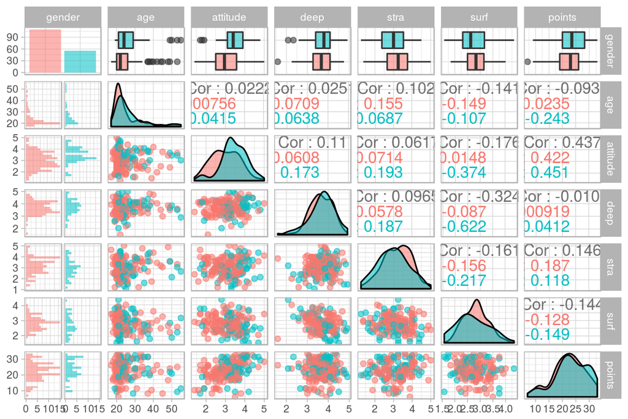

```r
library(ggplot2)
library(GGally)
theme_set(theme_light(base_size=9))
ggpairs(learning2014, mapping = aes(col = gender, alpha = 0.3), lower = list(combo = wrap("facethist", bins = 20)))
```

### Fitting a regression

In this section we try to find a suitable regression formula that summarizes the performance (points) of the students well. We start by trying out some models (commented out) and finally arrive to a model we believe is a good approximation on the variables that have a biggest effect on performance based on statistical signifficance of the variables used.

```r
model1 <- lm(points ~ deep + surf + gender, data = learning2014)
summary(model1)
```

```
##
## Call:
## lm(formula = points ~ deep + surf + gender, data = learning2014)
##
## Residuals:
##      Min       1Q   Median       3Q      Max
## -14.8988  -3.6363   0.3912   4.2481  10.7905
##
## Coefficients:
##             Estimate Std. Error t value Pr(>|t|)
## (Intercept)  29.8145     4.7353   6.296 2.75e-09 ***
## deep         -0.6964     0.8700  -0.800   0.4246
## surf         -1.7461     0.9159  -1.906   0.0584 .
## genderM       0.9827     0.9680   1.015   0.3115
## ---
## Signif. codes:  0 '***' 0.001 '**' 0.01 '*' 0.05 '.' 0.1 ' ' 1
##
## Residual standard error: 5.857 on 162 degrees of freedom
## Multiple R-squared:  0.03062,    Adjusted R-squared:  0.01267
## F-statistic: 1.706 on 3 and 162 DF,  p-value: 0.1679
```

```r
#remove unsignifficant variables and try a different model

model2 <- lm(points ~ surf + age + stra, data = learning2014 )
summary(model2)
```

```
##
## Call:
## lm(formula = points ~ surf + age + stra, data = learning2014)
##
## Residuals:
##      Min       1Q   Median       3Q      Max
## -15.8229  -3.5885   0.4698   4.1271   9.7896
##
## Coefficients:
##             Estimate Std. Error t value Pr(>|t|)
## (Intercept) 26.28166    3.68767   7.127  3.2e-11 ***
## surf        -1.56432    0.87103  -1.796   0.0744 .
## age         -0.09642    0.05885  -1.638   0.1033
## stra         1.04286    0.59393   1.756   0.0810 .
## ---
## Signif. codes:  0 '***' 0.001 '**' 0.01 '*' 0.05 '.' 0.1 ' ' 1
##
## Residual standard error: 5.792 on 162 degrees of freedom
## Multiple R-squared:  0.05205,    Adjusted R-squared:  0.03449
## F-statistic: 2.965 on 3 and 162 DF,  p-value: 0.03377
```

```r
#remove unsignifficant variables and try a different model

model3 <- lm(points ~ surf + stra + attitude, data = learning2014 )
summary(model3)
```

```
##
## Call:
## lm(formula = points ~ surf + stra + attitude, data = learning2014)
##
## Residuals:
##      Min       1Q   Median       3Q      Max
## -17.1550  -3.4346   0.5156   3.6401  10.8952
##
## Coefficients:
##             Estimate Std. Error t value Pr(>|t|)
## (Intercept)  11.0171     3.6837   2.991  0.00322 **
## surf         -0.5861     0.8014  -0.731  0.46563
## stra          0.8531     0.5416   1.575  0.11716
## attitude      3.3952     0.5741   5.913 1.93e-08 ***
## ---
## Signif. codes:  0 '***' 0.001 '**' 0.01 '*' 0.05 '.' 0.1 ' ' 1
##
## Residual standard error: 5.296 on 162 degrees of freedom
## Multiple R-squared:  0.2074, Adjusted R-squared:  0.1927
## F-statistic: 14.13 on 3 and 162 DF,  p-value: 3.156e-08
```

```r
#remove unsignifficant variables and try a different model

model4 <- lm(points ~ attitude + deep + gender, data = learning2014 )
summary(model4)
```

```
##
## Call:
## lm(formula = points ~ attitude + deep + gender, data = learning2014)
##
## Residuals:
##      Min       1Q   Median       3Q      Max
## -17.0364  -3.2315   0.3561   3.9436  11.0859
##
## Coefficients:
##             Estimate Std. Error t value Pr(>|t|)
## (Intercept)  13.6240     3.1799   4.284 3.13e-05 ***
## attitude      3.6657     0.5984   6.125 6.61e-09 ***
## deep         -0.6172     0.7546  -0.818    0.415
## genderM      -0.4633     0.9170  -0.505    0.614
## ---
## Signif. codes:  0 '***' 0.001 '**' 0.01 '*' 0.05 '.' 0.1 ' ' 1
##
## Residual standard error: 5.337 on 162 degrees of freedom
## Multiple R-squared:  0.1953, Adjusted R-squared:  0.1804
## F-statistic:  13.1 on 3 and 162 DF,  p-value: 1.054e-07
```

```r
#remove unsignifficant variables and try a different model

my_model <- lm(points ~ age + attitude + stra, data= learning2014)
summary(my_model)
```

```
##
## Call:
## lm(formula = points ~ age + attitude + stra, data = learning2014)
##
## Residuals:
##      Min       1Q   Median       3Q      Max
## -18.1149  -3.2003   0.3303   3.4129  10.7599
##
## Coefficients:
##             Estimate Std. Error t value Pr(>|t|)
## (Intercept) 10.89543    2.64834   4.114 6.17e-05 ***
## age         -0.08822    0.05302  -1.664   0.0981 .
## attitude     3.48077    0.56220   6.191 4.72e-09 ***
## stra         1.00371    0.53434   1.878   0.0621 .
## ---
## Signif. codes:  0 '***' 0.001 '**' 0.01 '*' 0.05 '.' 0.1 ' ' 1
##
## Residual standard error: 5.26 on 162 degrees of freedom
## Multiple R-squared:  0.2182, Adjusted R-squared:  0.2037
## F-statistic: 15.07 on 3 and 162 DF,  p-value: 1.07e-08
```

The iterated model is

> points ~ age + attitude + stra

### Interpretation of the linear regression model

We can interpret our model as follows: if we have one point higher attitude (Likert scale), our test scores are on average three and a half points higher with a standard error of roughly 0.56. Age and strategic behaviour are statistically signifficant at p-value 10%, thus we exclude their interpretations since it might be just chance these variables have an effect on test scores which differs from zero. The adjusted R-squared, or the goodness-of-fit, is 0.2037 and the F-statistic is statistically signifficant. This means that the fit is good and it has statistical signifficance in explaining the test score performance. Note that the normal R-squared increases as one adds variables to the model, the adjusted one does not.

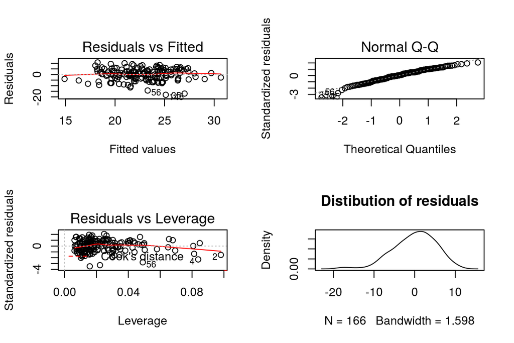

```r
library(ggplot2)
par(mfrow = c(2,2))
plot(my_model, which(c(T,T,F,F,T,F)))


plot(density(my_model$residuals), main="Distibution of residuals")
```

In the plot with fitted values and residuals it is fairly clear that there is no apparent pattern between the two. This suggests that the size of the errors do not depend greatly on the explanatory variables used. We can see from the Q-Q plot that there is a reasonable fit on the line, meaning that the residuals are roughly normally distributed. This is demonstrated on the fourth plot where one can see the distribution of the residuals. On the leverage plot one can see that there are couple of observations which are quite different meaning that these observations might have a big impact on the results, though the numbers are small and we can still be confident in our model.

We can be fairly confident in our model that attitude has the biggest effect on exam performance. Multiple diagnostics of this model confirmed that there are no apparent reason to doubt that the residuals are correlated with the explanatory variables, the residuals are not normally distributed, or our results are based on very high impacting or leveraging outliers.

# Chapter 3: Log-regression

### Preliminary actions

```r
library(dplyr)
summarise(group_by(alc, high_use), testin_k_arvo = mean(G3), testin_hajonta = sd(G3))
```

```
## # A tibble: 2 × 3
##   high_use testin_k_arvo testin_hajonta
##      <lgl>         <dbl>          <dbl>
## 1    FALSE      11.73507       3.385467
## 2     TRUE      10.80702       3.042115
```

```r
tarkasteltavat_muuttujat <- c("high_use","G3","Medu","sex","absences","freetime","goout")
data <- select(alc, one_of(tarkasteltavat_muuttujat))
glimpse(data)
```

```
## Observations: 382
## Variables: 7
## $ high_use <lgl> FALSE, FALSE, TRUE, FALSE, FALSE, FALSE, FALSE, FALSE...
## $ G3       <int> 8, 8, 11, 14, 12, 14, 12, 10, 18, 14, 12, 12, 13, 12,...
## $ Medu     <int> 4, 1, 1, 4, 3, 4, 2, 4, 3, 3, 4, 2, 4, 4, 2, 4, 4, 3,...
## $ sex      <fctr> F, F, F, F, F, M, M, F, M, M, F, F, M, M, M, F, F, F...
## $ absences <int> 5, 3, 8, 1, 2, 8, 0, 4, 0, 0, 1, 2, 1, 1, 0, 5, 8, 3,...
## $ freetime <int> 3, 3, 3, 2, 3, 4, 4, 1, 2, 5, 3, 2, 3, 4, 5, 4, 2, 3,...
## $ goout    <int> 4, 3, 2, 2, 2, 2, 4, 4, 2, 1, 3, 2, 3, 3, 2, 4, 3, 2,...
```

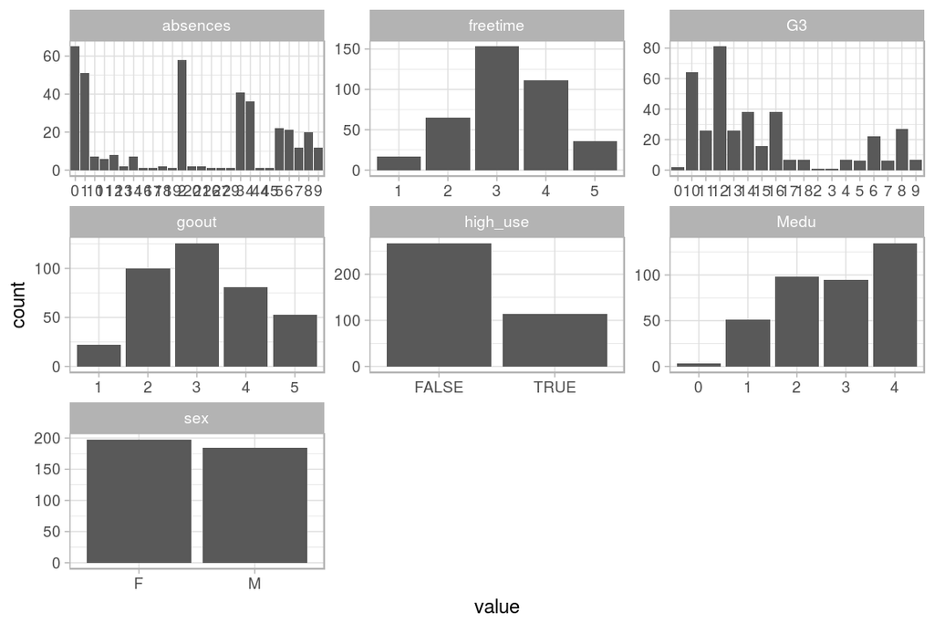

```r
library(ggplot2)
library(tidyr)
gather(data) %>% ggplot(aes(value)) + facet_wrap("key", scales = "free") +geom_bar()
```

Next we check the frequencies of high usage among different sexes and variables: grades (G3), absences, and Mothers education. We also plot boxplots to check the distribution among these subgroups.

```r
data %>% group_by(sex,high_use) %>% summarise(count = n(),mean_grade = mean(G3))
```

```
## Source: local data frame [4 x 4]
## Groups: sex [?]
##
##      sex high_use count mean_grade
##   <fctr>    <lgl> <int>      <dbl>
## 1      F    FALSE   156   11.39744
## 2      F     TRUE    42   11.71429
## 3      M    FALSE   112   12.20536
## 4      M     TRUE    72   10.27778
```

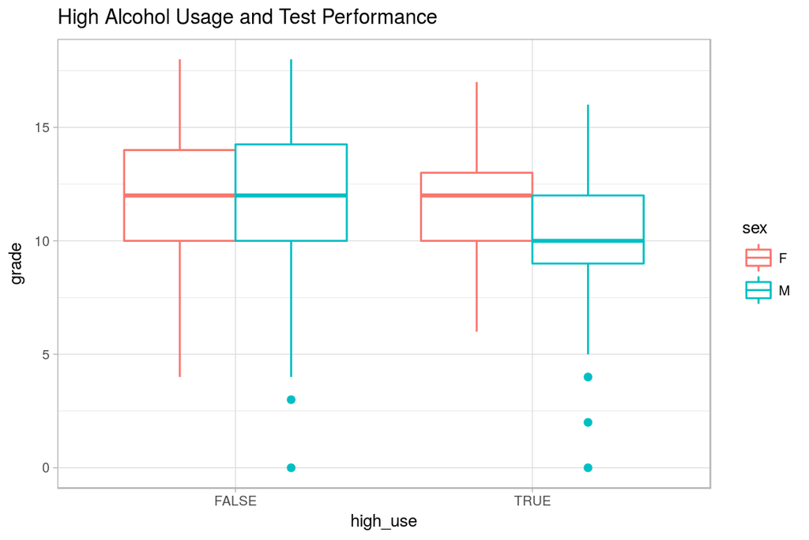

```r
ggplot(alc, aes(x = high_use, y = G3, col=sex)) + geom_boxplot() + ylab("grade") + ggtitle("High Alcohol Usage and Test Performance")
```

```r
data %>% group_by(sex,high_use) %>% summarise(count = n(), mean_absences = mean(absences))
```

```
## Source: local data frame [4 x 4]
## Groups: sex [?]
##
##      sex high_use count mean_absences
##   <fctr>    <lgl> <int>         <dbl>
## 1      F    FALSE   156      4.224359
## 2      F     TRUE    42      6.785714
## 3      M    FALSE   112      2.982143
## 4      M     TRUE    72      6.125000
```

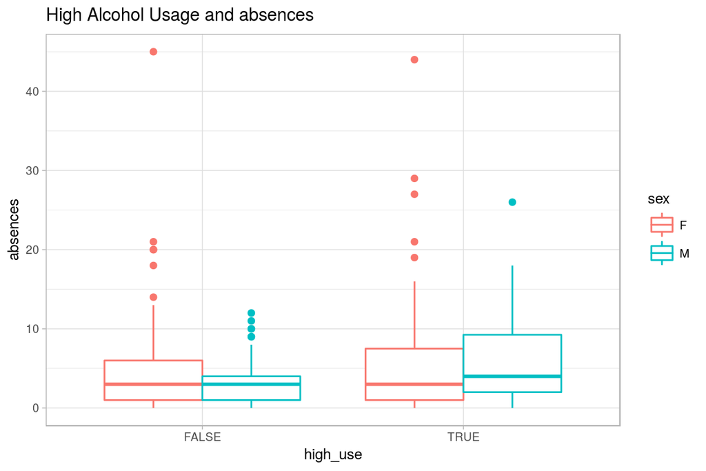

```r
ggplot(alc, aes(x = high_use, y = absences, col=sex)) + geom_boxplot() + ylab("absences") + ggtitle("High Alcohol Usage and absences")
```

```r
data %>% group_by(sex,high_use) %>% summarise(count = n(), mean_mothersEdu = mean(Medu))
```

```
## Source: local data frame [4 x 4]
## Groups: sex [?]
##
##      sex high_use count mean_mothersEdu
##   <fctr>    <lgl> <int>           <dbl>
## 1      F    FALSE   156        2.673077
## 2      F     TRUE    42        2.785714
## 3      M    FALSE   112        2.973214
## 4      M     TRUE    72        2.847222
```

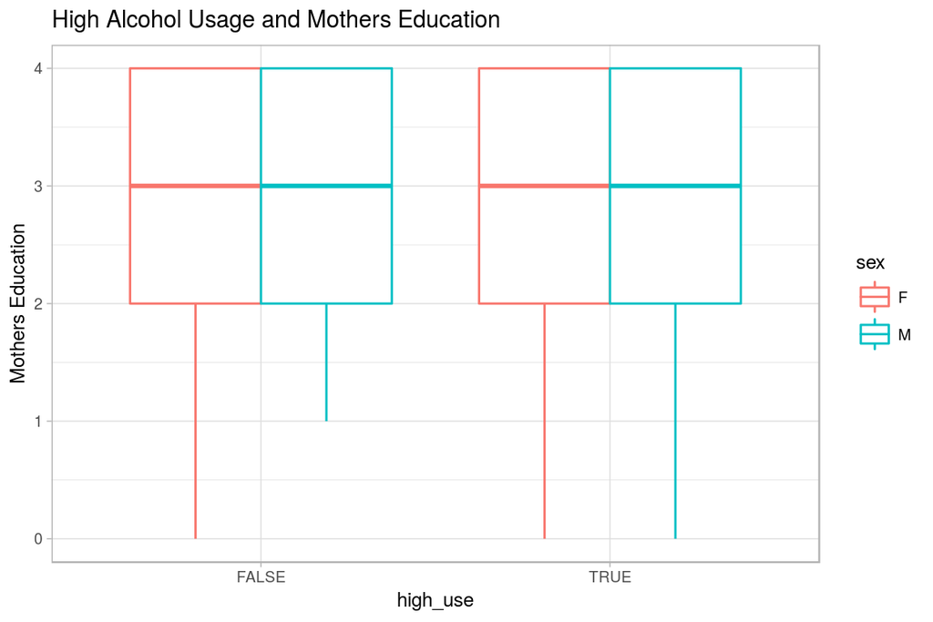

```r
ggplot(alc, aes(x = high_use, y = Medu, col=sex)) + geom_boxplot() + ylab("Mothers Education") + ggtitle("High Alcohol Usage and Mothers Education")
```

```r
data %>% group_by(sex,high_use) %>% summarise(count = n(), mean_freetime = mean(freetime))
```

```
## Source: local data frame [4 x 4]
## Groups: sex [?]
##
##      sex high_use count mean_freetime
##   <fctr>    <lgl> <int>         <dbl>
## 1      F    FALSE   156      2.929487
## 2      F     TRUE    42      3.357143
## 3      M    FALSE   112      3.392857
## 4      M     TRUE    72      3.500000
```

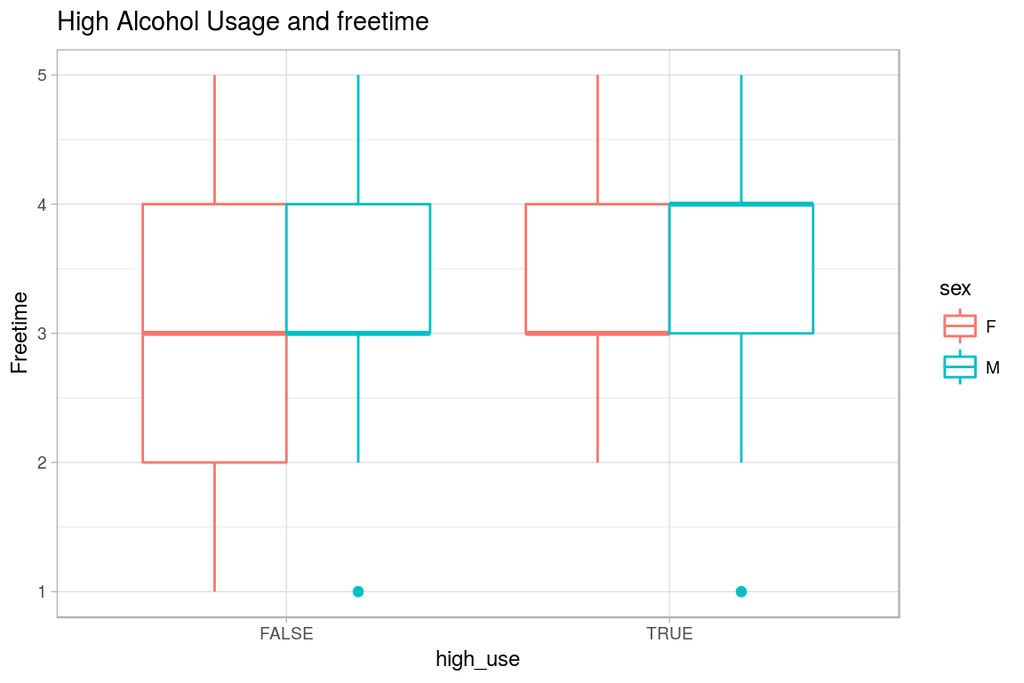

```r
  ggplot(alc, aes(x = high_use, y = freetime, col=sex)) + geom_boxplot() + ylab("Freetime") + ggtitle("High Alcohol Usage and freetime")
```

```r
  data %>% group_by(sex,high_use) %>% summarise(count = n(), mean_goout = mean(goout))
```

```
## Source: local data frame [4 x 4]
## Groups: sex [?]
##
##      sex high_use count mean_goout
##   <fctr>    <lgl> <int>      <dbl>
## 1      F    FALSE   156   2.955128
## 2      F     TRUE    42   3.357143
## 3      M    FALSE   112   2.714286
## 4      M     TRUE    72   3.930556
```

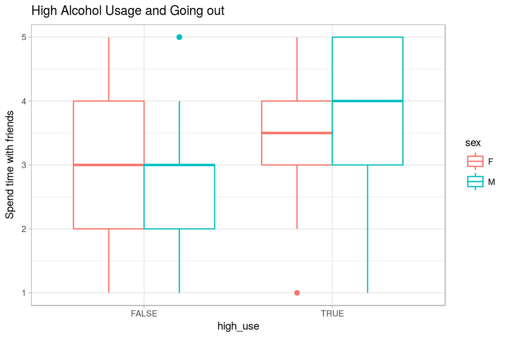

```r
  ggplot(alc, aes(x = high_use, y = goout, col=sex)) + geom_boxplot() + ylab("Spend time with friends") + ggtitle("High Alcohol Usage and Going out")
```

It appears that test performance is lowe especially for men for high users of alcohol. Similar effect can be found for absences; high users of acohol are more likely to miss classes, especially for men. We did not find a clear difference based on Mothers education (our initial hypothesis seems to have been wrong) and therefore change our attention to freetime. High users seem to have more freetime, this might be due to neglect of work or just plain boredom. Similarly, individuals which are more social or have less preference to study tend to be higher drinkers.

### The model

Next we fit a logistic model to explain high usage of alcohol. Our model is the following

> high_use ~ freetime + absences + sex + goout

```r
# find the model with glm()
m <- glm(high_use ~ freetime + absences + sex + goout, data = alc, family = "binomial")

# print out a summary of the model
summary(m)
```

```
##
## Call:
## glm(formula = high_use ~ freetime + absences + sex + goout, family = "binomial",
##     data = alc)
##
## Deviance Residuals:
##     Min       1Q   Median       3Q      Max
## -1.7938  -0.8060  -0.5306   0.8297   2.4887
##
## Coefficients:
##             Estimate Std. Error z value Pr(>|z|)
## (Intercept) -4.33104    0.57522  -7.529 5.10e-14 ***
## freetime     0.07254    0.13705   0.529 0.596610
## absences     0.08487    0.02240   3.789 0.000151 ***
## sexM         0.93806    0.25762   3.641 0.000271 ***
## goout        0.71094    0.12444   5.713 1.11e-08 ***
## ---
## Signif. codes:  0 '***' 0.001 '**' 0.01 '*' 0.05 '.' 0.1 ' ' 1
##
## (Dispersion parameter for binomial family taken to be 1)
##
##     Null deviance: 465.68  on 381  degrees of freedom
## Residual deviance: 387.47  on 377  degrees of freedom
## AIC: 397.47
##
## Number of Fisher Scoring iterations: 4
```

```r
# print out the coefficients of the model
coef(m)
```

```
## (Intercept)    freetime    absences        sexM       goout
## -4.33104146  0.07253827  0.08487446  0.93806336  0.71094375
```

```r
#ODDS ratio of 1/6, individual is 1/6 likely to succeed with X, the exponent of the coefficients: exp(beta) = odds(Y|x+1)/odds(Y|x)

# compute odds ratios (OR)
OR <- coef(m) %>% exp

# compute confidence intervals (CI)
CI <- confint(m) %>% exp
# print out the odds ratios with their confidence intervals
cbind(OR, CI)
```

```
##                     OR      2.5 %     97.5 %
## (Intercept) 0.01315384 0.00406496 0.03896248
## freetime    1.07523395 0.82191021 1.40863837
## absences    1.08858040 1.04303580 1.14007640
## sexM        2.55502845 1.55086699 4.26706152
## goout       2.03591174 1.60487130 2.61688539
```

When goout (spending time with friends) is included in the model it seems that freetime does not have explanatory power in the model. From the print above, one can see that amount of absences, gender, and social activity seem to explain alcohol usage quite well. For example, an individual answering that they spend more time with friends (Likert scale) are twice as likely to use high amounts of alcohol, everything else held constant. Likewise, males are much more likely to spend more alcohol and students who are absent have a small risk factor. Note that freetime is not signifficant at p-value 10% (or 5%) and the confidence interwal includes 1 for odds ratios, which means that the model suggest that there is no clear causality weather students whom spend more freetime have a higher or lower risk to consume high amounts of alchol. The results show that the initial hypothesis on social behaviour, gender, and amount absences seem to be correct but ones on Mothers education (based on the graph above) or freetime spent were not.

### Validation

Now we try to make predictions and cross-validation based on the model used.

```r
# find the model with glm()
m <- glm(high_use ~ freetime + absences + sex + goout, data = alc, family = "binomial")

# predict() the probability of high_use
probabilities <- predict(m, type = "response")

# add the predicted probabilities to 'alc'
alc <- mutate(alc, probability = probabilities)

# use the probabilities to make a prediction of high_use
alc <- mutate(alc, prediction = probability > 0.5)

# tabulate the target variable versus the predictions
table(high_use = alc$high_use, prediction = alc$prediction)
```

```
##         prediction
## high_use FALSE TRUE
##    FALSE   250   18
##    TRUE     64   50
```

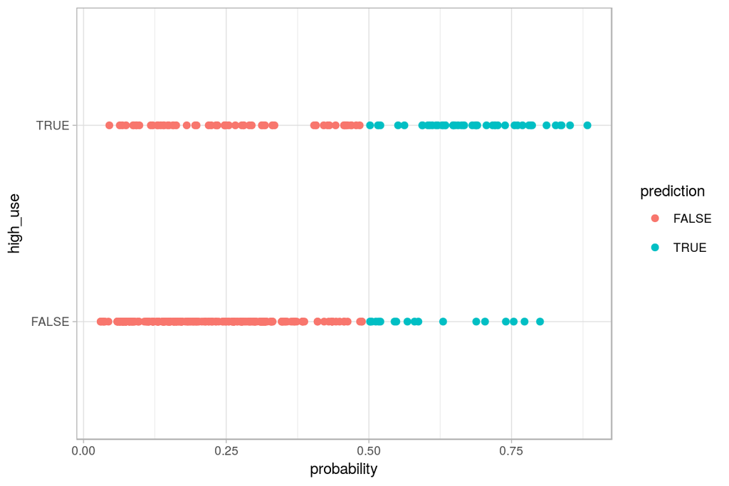

```r
# initialize a plot of 'high_use' versus 'probability' in 'alc'
g <- ggplot(alc, aes(x = probability, y = high_use, col=prediction))

# define the geom as points and draw the plot
g + geom_point()
```

```r
# tabulate the target variable versus the predictions
table(high_use = alc$high_use, prediction = alc$prediction) %>% prop.table %>% addmargins()
```

```
##         prediction
## high_use      FALSE       TRUE        Sum
##    FALSE 0.65445026 0.04712042 0.70157068
##    TRUE  0.16753927 0.13089005 0.29842932
##    Sum   0.82198953 0.17801047 1.00000000
```

```r
# define a loss function (mean prediction error)
loss_func <- function(class, prob) {
  n_wrong <- abs(class - prob) > 0.5
  mean(n_wrong)
}

# call loss_func to compute the average number of wrong predictions in the (training) data
loss_func(class = alc$high_use, prob = alc$probability)
```

```
## [1] 0.2146597
```

```r
# K-fold cross-validation
library(boot)
cv <- cv.glm(data = alc, cost = loss_func, glmfit = m, K = 10)

# average number of wrong predictions in the cross validation
cv$delta[1]
```

```
## [1] 0.2146597
```

# Chapter 4: Clustering

### Preliminaries

```r
library(MASS)
```

```r
library(dplyr)
library(tidyr)
library(ggplot2)
library(corrplot)
data("Boston")
dim(Boston)
```

```
## [1] 506  14
```

```r
str(Boston)
```

```
## 'data.frame':    506 obs. of  14 variables:
##  $ crim   : num  0.00632 0.02731 0.02729 0.03237 0.06905 ...
##  $ zn     : num  18 0 0 0 0 0 12.5 12.5 12.5 12.5 ...
##  $ indus  : num  2.31 7.07 7.07 2.18 2.18 2.18 7.87 7.87 7.87 7.87 ...
##  $ chas   : int  0 0 0 0 0 0 0 0 0 0 ...
##  $ nox    : num  0.538 0.469 0.469 0.458 0.458 0.458 0.524 0.524 0.524 0.524 ...
##  $ rm     : num  6.58 6.42 7.18 7 7.15 ...
##  $ age    : num  65.2 78.9 61.1 45.8 54.2 58.7 66.6 96.1 100 85.9 ...
##  $ dis    : num  4.09 4.97 4.97 6.06 6.06 ...
##  $ rad    : int  1 2 2 3 3 3 5 5 5 5 ...
##  $ tax    : num  296 242 242 222 222 222 311 311 311 311 ...
##  $ ptratio: num  15.3 17.8 17.8 18.7 18.7 18.7 15.2 15.2 15.2 15.2 ...
##  $ black  : num  397 397 393 395 397 ...
##  $ lstat  : num  4.98 9.14 4.03 2.94 5.33 ...
##  $ medv   : num  24 21.6 34.7 33.4 36.2 28.7 22.9 27.1 16.5 18.9 ...
```

```r
glimpse(Boston)
```

```
## Observations: 506
## Variables: 14
## $ crim    <dbl> 0.00632, 0.02731, 0.02729, 0.03237, 0.06905, 0.02985, ...
## $ zn      <dbl> 18.0, 0.0, 0.0, 0.0, 0.0, 0.0, 12.5, 12.5, 12.5, 12.5,...
## $ indus   <dbl> 2.31, 7.07, 7.07, 2.18, 2.18, 2.18, 7.87, 7.87, 7.87, ...
## $ chas    <int> 0, 0, 0, 0, 0, 0, 0, 0, 0, 0, 0, 0, 0, 0, 0, 0, 0, 0, ...
## $ nox     <dbl> 0.538, 0.469, 0.469, 0.458, 0.458, 0.458, 0.524, 0.524...
## $ rm      <dbl> 6.575, 6.421, 7.185, 6.998, 7.147, 6.430, 6.012, 6.172...
## $ age     <dbl> 65.2, 78.9, 61.1, 45.8, 54.2, 58.7, 66.6, 96.1, 100.0,...
## $ dis     <dbl> 4.0900, 4.9671, 4.9671, 6.0622, 6.0622, 6.0622, 5.5605...
## $ rad     <int> 1, 2, 2, 3, 3, 3, 5, 5, 5, 5, 5, 5, 5, 4, 4, 4, 4, 4, ...
## $ tax     <dbl> 296, 242, 242, 222, 222, 222, 311, 311, 311, 311, 311,...
## $ ptratio <dbl> 15.3, 17.8, 17.8, 18.7, 18.7, 18.7, 15.2, 15.2, 15.2, ...
## $ black   <dbl> 396.90, 396.90, 392.83, 394.63, 396.90, 394.12, 395.60...
## $ lstat   <dbl> 4.98, 9.14, 4.03, 2.94, 5.33, 5.21, 12.43, 19.15, 29.9...
## $ medv    <dbl> 24.0, 21.6, 34.7, 33.4, 36.2, 28.7, 22.9, 27.1, 16.5, ...
```

```r
summary(Boston)
```

```
##       crim                zn             indus            chas
##  Min.   : 0.00632   Min.   :  0.00   Min.   : 0.46   Min.   :0.00000
##  1st Qu.: 0.08204   1st Qu.:  0.00   1st Qu.: 5.19   1st Qu.:0.00000
##  Median : 0.25651   Median :  0.00   Median : 9.69   Median :0.00000
##  Mean   : 3.61352   Mean   : 11.36   Mean   :11.14   Mean   :0.06917
##  3rd Qu.: 3.67708   3rd Qu.: 12.50   3rd Qu.:18.10   3rd Qu.:0.00000
##  Max.   :88.97620   Max.   :100.00   Max.   :27.74   Max.   :1.00000
##       nox               rm             age              dis
##  Min.   :0.3850   Min.   :3.561   Min.   :  2.90   Min.   : 1.130
##  1st Qu.:0.4490   1st Qu.:5.886   1st Qu.: 45.02   1st Qu.: 2.100
##  Median :0.5380   Median :6.208   Median : 77.50   Median : 3.207
##  Mean   :0.5547   Mean   :6.285   Mean   : 68.57   Mean   : 3.795
##  3rd Qu.:0.6240   3rd Qu.:6.623   3rd Qu.: 94.08   3rd Qu.: 5.188
##  Max.   :0.8710   Max.   :8.780   Max.   :100.00   Max.   :12.127
##       rad              tax           ptratio          black
##  Min.   : 1.000   Min.   :187.0   Min.   :12.60   Min.   :  0.32
##  1st Qu.: 4.000   1st Qu.:279.0   1st Qu.:17.40   1st Qu.:375.38
##  Median : 5.000   Median :330.0   Median :19.05   Median :391.44
##  Mean   : 9.549   Mean   :408.2   Mean   :18.46   Mean   :356.67
##  3rd Qu.:24.000   3rd Qu.:666.0   3rd Qu.:20.20   3rd Qu.:396.23
##  Max.   :24.000   Max.   :711.0   Max.   :22.00   Max.   :396.90
##      lstat            medv
##  Min.   : 1.73   Min.   : 5.00
##  1st Qu.: 6.95   1st Qu.:17.02
##  Median :11.36   Median :21.20
##  Mean   :12.65   Mean   :22.53
##  3rd Qu.:16.95   3rd Qu.:25.00
##  Max.   :37.97   Max.   :50.00
```

[figure not shown]

```r
pairs(Boston)
```

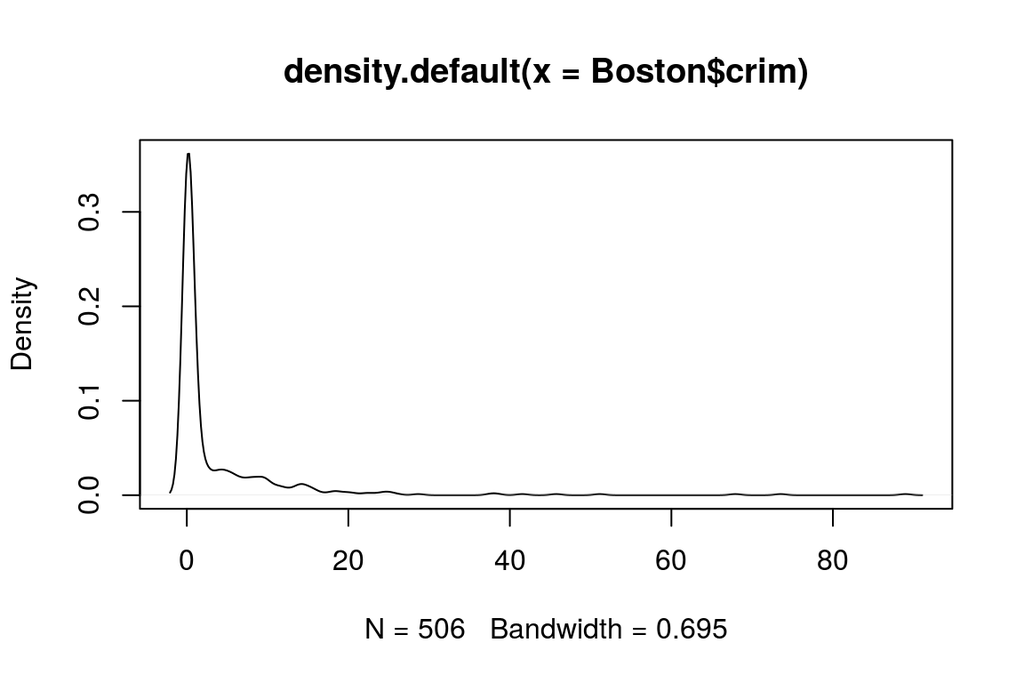

```r
plot(density(Boston$crim))
```

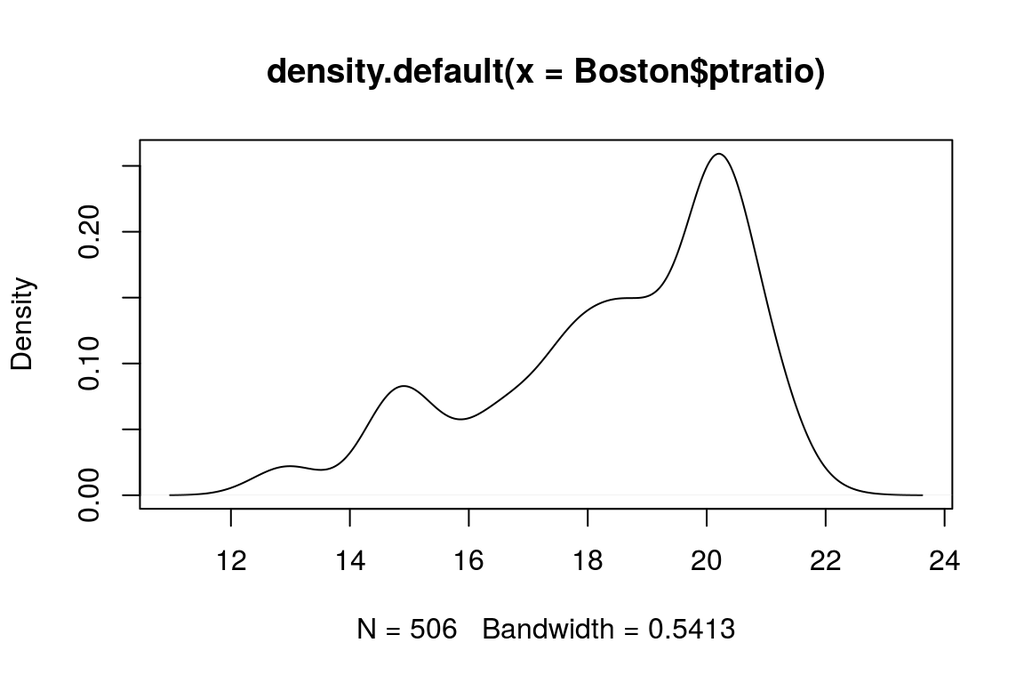

```r
plot(density(Boston$ptratio))
```

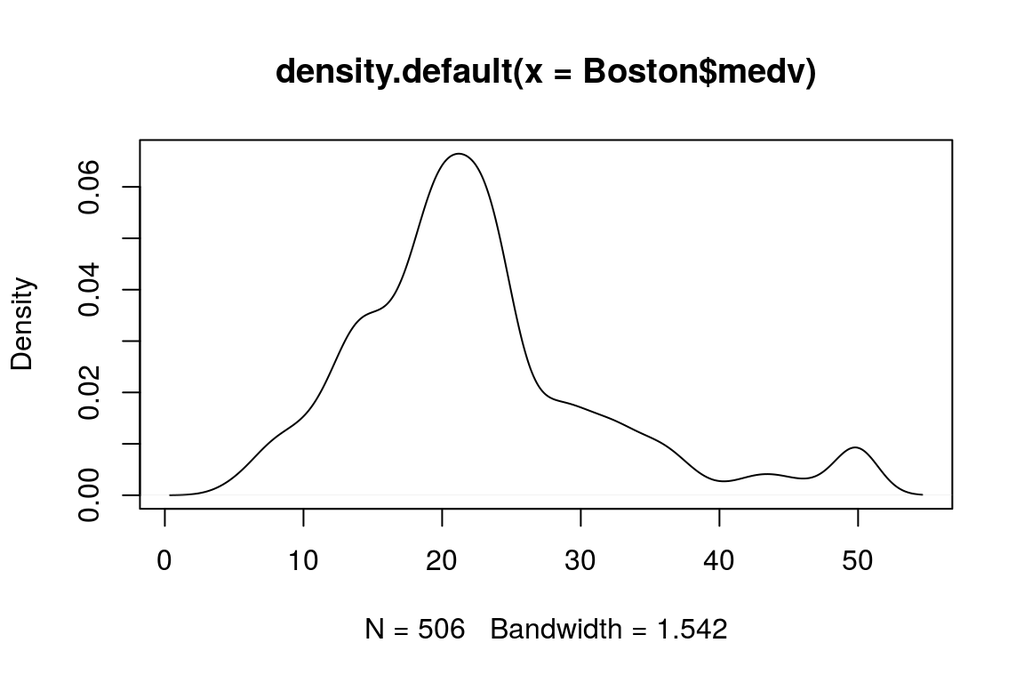

```r
plot(density(Boston$medv))
```

### Correlations, factoring, and dividing the data to test and training sets

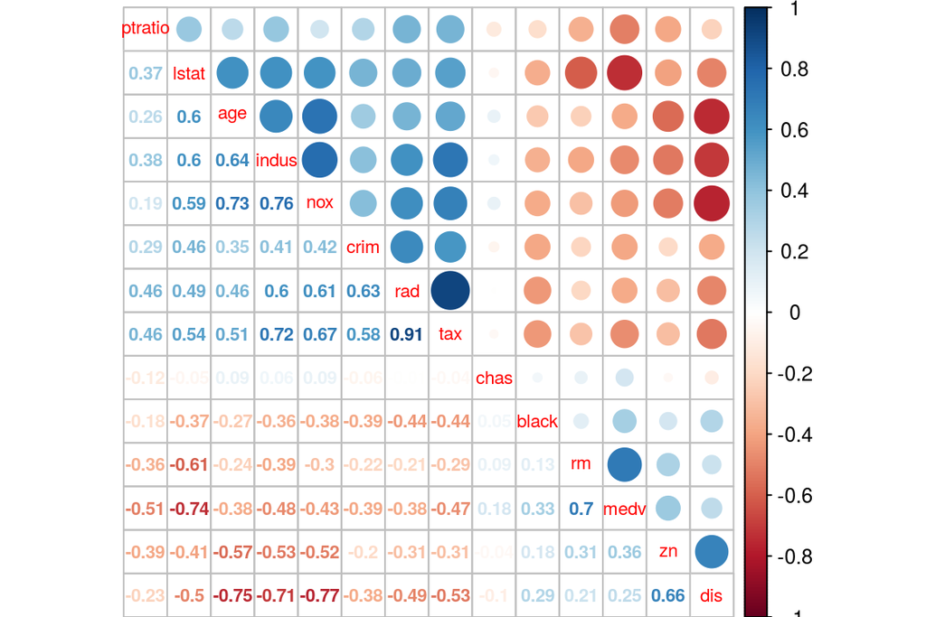

```r
#calculate the correlations and plot them
cor_matrix <- cor(Boston)
cor_matrix %>% round(digits=2) %>% corrplot.mixed(tl.cex = 0.7,number.cex=0.7,order="hclust",addrect=2)
```

From the correlation pairs plot we can see the relevant correlations between the variables. As one could expect industrial areas are related to nitrogen oxides concentration and negatively correlated with residential areas and employment centers. Crime is correlated among others with radial highways and industrial areas.

Next we standardize the data sets. The distributions are easier to see with standardized variables. Let’s divide the crime variable to a factor of size four: “low” to “high”. We divide the data to trainingsets and testsets with a share of 80%.

```r
boston_scaled <- scale(Boston)
summary(boston_scaled)
```

```
##       crim                 zn               indus
##  Min.   :-0.419367   Min.   :-0.48724   Min.   :-1.5563
##  1st Qu.:-0.410563   1st Qu.:-0.48724   1st Qu.:-0.8668
##  Median :-0.390280   Median :-0.48724   Median :-0.2109
##  Mean   : 0.000000   Mean   : 0.00000   Mean   : 0.0000
##  3rd Qu.: 0.007389   3rd Qu.: 0.04872   3rd Qu.: 1.0150
##  Max.   : 9.924110   Max.   : 3.80047   Max.   : 2.4202
##       chas              nox                rm               age
##  Min.   :-0.2723   Min.   :-1.4644   Min.   :-3.8764   Min.   :-2.3331
##  1st Qu.:-0.2723   1st Qu.:-0.9121   1st Qu.:-0.5681   1st Qu.:-0.8366
##  Median :-0.2723   Median :-0.1441   Median :-0.1084   Median : 0.3171
##  Mean   : 0.0000   Mean   : 0.0000   Mean   : 0.0000   Mean   : 0.0000
##  3rd Qu.:-0.2723   3rd Qu.: 0.5981   3rd Qu.: 0.4823   3rd Qu.: 0.9059
##  Max.   : 3.6648   Max.   : 2.7296   Max.   : 3.5515   Max.   : 1.1164
##       dis               rad               tax             ptratio
##  Min.   :-1.2658   Min.   :-0.9819   Min.   :-1.3127   Min.   :-2.7047
##  1st Qu.:-0.8049   1st Qu.:-0.6373   1st Qu.:-0.7668   1st Qu.:-0.4876
##  Median :-0.2790   Median :-0.5225   Median :-0.4642   Median : 0.2746
##  Mean   : 0.0000   Mean   : 0.0000   Mean   : 0.0000   Mean   : 0.0000
##  3rd Qu.: 0.6617   3rd Qu.: 1.6596   3rd Qu.: 1.5294   3rd Qu.: 0.8058
##  Max.   : 3.9566   Max.   : 1.6596   Max.   : 1.7964   Max.   : 1.6372
##      black             lstat              medv
##  Min.   :-3.9033   Min.   :-1.5296   Min.   :-1.9063
##  1st Qu.: 0.2049   1st Qu.:-0.7986   1st Qu.:-0.5989
##  Median : 0.3808   Median :-0.1811   Median :-0.1449
##  Mean   : 0.0000   Mean   : 0.0000   Mean   : 0.0000
##  3rd Qu.: 0.4332   3rd Qu.: 0.6024   3rd Qu.: 0.2683
##  Max.   : 0.4406   Max.   : 3.5453   Max.   : 2.9865
```

```r
boston_scaled <- as.data.frame(boston_scaled)
scaled_crim <- boston_scaled$crim
summary(scaled_crim)
```

```
##      Min.   1st Qu.    Median      Mean   3rd Qu.      Max.
## -0.419400 -0.410600 -0.390300  0.000000  0.007389  9.924000
```

```r
bins <- quantile(scaled_crim)
bins
```

```
##           0%          25%          50%          75%         100%
## -0.419366929 -0.410563278 -0.390280295  0.007389247  9.924109610
```

```r
crime <- cut(scaled_crim, breaks= bins, include.lowest = TRUE, labels = c("low", "med_low", "med_high", "high"))
crime
```

[output not shown]

[output cut: 59 more lines]

```r
boston_scaled <- dplyr::select(boston_scaled, -crim)
boston_scaled <- data.frame(boston_scaled, crime)

n <- nrow(boston_scaled)
n
```

```
## [1] 506
```

```r
index <- sample(n, size = n * 0.8)
index
```

[output not shown]

```r
trainingset <- boston_scaled[index,]
testset <- boston_scaled[-index,]

correct_classes <- testset$crime
testset <- dplyr::select(testset, -crime)
```

### The Linear Discriminant Analysis

Next we fit a lda model. We try to expain crime rate with other variables in the data. First level LDA does a good job on dividing the data. There are two main ‘groups’ high crime areas are vastly different from the rest groups. We can see that high crime is closely related to being close to radial highways (variable rad). This seems to be the dividing factor. From the testset and prediction table we can see that prediction of high crime is accurate but there is some dispersion in the med_high to low crime predictions. Our model seems to work quite adequately.

```r
lda.fit <- lda(crime ~ ., data = trainingset)
lda.fit
```

```
## Call:
## lda(crime ~ ., data = trainingset)
##
## Prior probabilities of groups:
##       low   med_low  med_high      high
## 0.2400990 0.2425743 0.2450495 0.2722772
##
## Group means:
##                  zn      indus        chas        nox         rm
## low       0.9168755 -0.9589503 -0.10997442 -0.9001245  0.4561365
## med_low  -0.1068150 -0.3083740  0.04906687 -0.5677359 -0.1788237
## med_high -0.3902253  0.2710479  0.16512651  0.4750908  0.0981352
## high     -0.4872402  1.0169558 -0.12916179  1.0350683 -0.4514522
##                 age        dis        rad        tax     ptratio
## low      -0.8842406  0.8906727 -0.6846906 -0.7357432 -0.46041376
## med_low  -0.3204684  0.3898526 -0.5447506 -0.5212466 -0.06854248
## med_high  0.4467536 -0.4106320 -0.4296790 -0.2975982 -0.32985562
## high      0.8160385 -0.8608592  1.6397657  1.5152267  0.78268316
##                black       lstat        medv
## low       0.38427077 -0.77183526  0.53133913
## med_low   0.31773753 -0.10889909 -0.03651884
## med_high  0.04063101 -0.02158984  0.16622731
## high     -0.74915729  0.91415368 -0.68728027
##
## Coefficients of linear discriminants:
##                 LD1         LD2         LD3
## zn       0.08537500  0.59400153 -0.99739116
## indus    0.12451366 -0.55933594  0.30470051
## chas    -0.10861089  0.00232055  0.23621390
## nox      0.33790005 -0.72501098 -1.21436564
## rm      -0.11227251 -0.08240853 -0.19355335
## age      0.16860589 -0.34812234 -0.03871428
## dis     -0.09745859 -0.26443911  0.32968861
## rad      3.34063836  0.88964496  0.08550445
## tax      0.07203432  0.15929144  0.21449093
## ptratio  0.11567190 -0.03468103 -0.25288763
## black   -0.10872827  0.05500639  0.13542172
## lstat    0.19081724 -0.07004642  0.47179925
## medv     0.18676847 -0.35775290 -0.18961211
##
## Proportion of trace:
##    LD1    LD2    LD3
## 0.9505 0.0374 0.0121
```

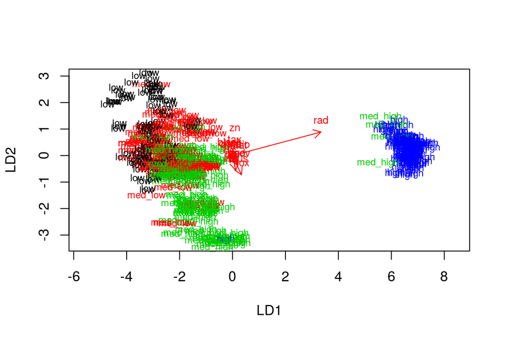

```r
lda.arrows <- function(x, myscale = 1, arrow_heads = 0.1, color = "red", tex = 0.75, choices = c(1,2)){
  heads <- coef(x)
  arrows(x0 = 0, y0 = 0,
         x1 = myscale * heads[,choices[1]],
         y1 = myscale * heads[,choices[2]], col=color, length = arrow_heads)
  text(myscale * heads[,choices], labels = row.names(heads),
       cex = tex, col=color, pos=3)
}

classes <- as.numeric(trainingset$crime)

plot(lda.fit, dimen =2, col = classes, pch = classes)
lda.arrows(lda.fit, myscale = 1)
```

```r
lda.pred <- predict(lda.fit, newdata = testset)

table(correct = correct_classes, predicted = lda.pred$class)
```

```
##           predicted
## correct    low med_low med_high high
##   low       19       7        4    0
##   med_low    9      13        6    0
##   med_high   0      13       12    2
##   high       0       0        0   17
```

### K-means clustering

Next we calculate the distance matrix to cluster the Boston data. As can be seen from pairs plot and ggpairs (this one is a bit messy), two centers seems to work quite well on the data. Number of centers is most appropriate when the total within sum of squares declines rapidly.

```r
library(MASS)
data('Boston')
dist_euclidian <- dist(Boston)
summary(dist_euclidian)
```

```
##    Min. 1st Qu.  Median    Mean 3rd Qu.    Max.
##   1.119  85.620 170.500 226.300 371.900 626.000
```

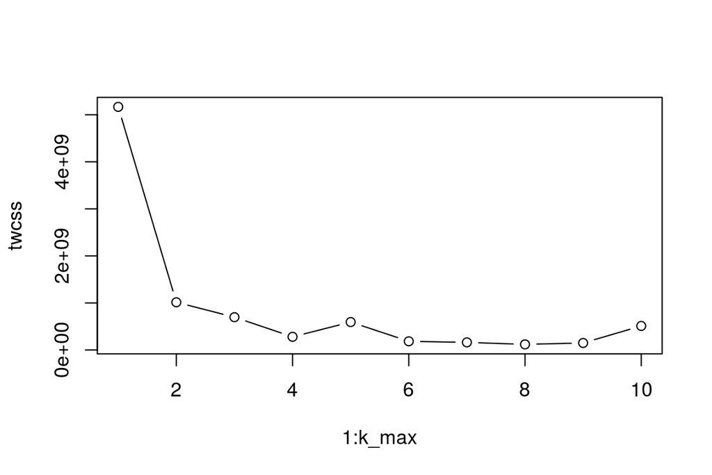

```r
k_max <- 10
twcss <- sapply(1:k_max, function(k){kmeans(dist_euclidian, k)$tot.withinss})

plot(1:k_max, twcss, type='b')
```

[figure not shown]

```r
km <- kmeans(dist_euclidian, centers=2)
pairs(Boston, col = c(km$cluster,alpha=0.2),pch=km$cluster)
```

```r
library(GGally)
data.frame(km$cluster)[,1]
```

[output not shown]

[output not shown]

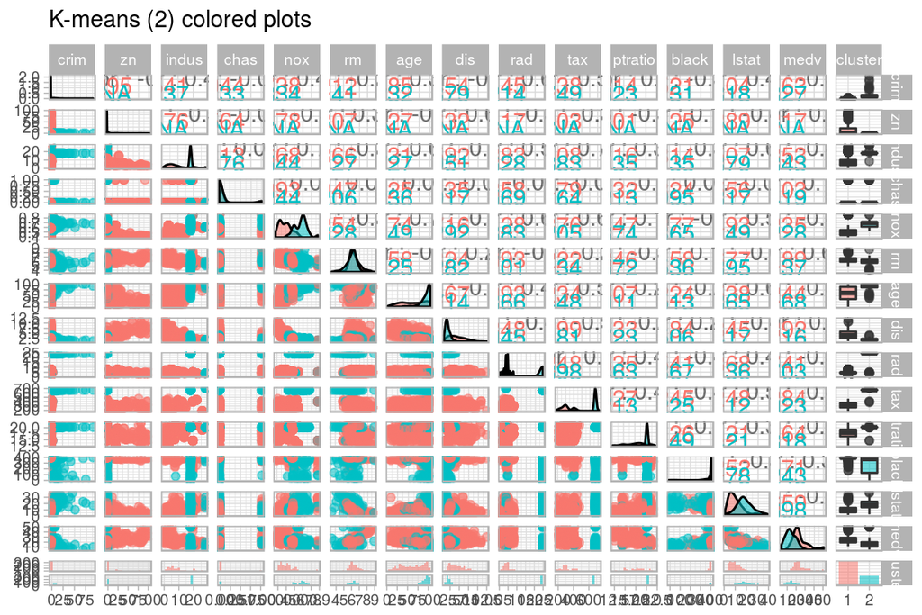

```r
Boston2 <- mutate(Boston, cluster = as.factor(data.frame(km$cluster)[,1]))
ggpairs(Boston2, mapping = aes(col = cluster, alpha = 0.3), lower = list(combo = wrap("facethist", bins = 20)), title ="K-means (2) colored plots")
```